# Machine learning for the smart building with Python, Scikit-learn and statsmodel

## B - Correlation and Regression

### Use case B.1 : basic correlation and linear regression between two temperature sensors and daily time series

#### Visual correlation of sensors s121 and s123 (temperatures in two rooms for 1 day)

- On the left : the two time series in the same diagram, with time as x axis and temperature as y
- On the right : correlation (cloud) of the points of the 2 TS, time is represented with colours - each point represents two temp. values (s121 and s123) at the same time index, indicated in color

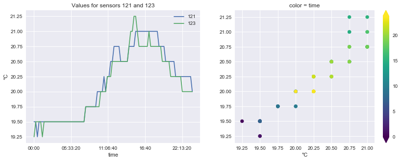

```python
s121.plot_compare_and_scatter(s123, day='2017-01-02')
```

```python
s121.corr(s123)
```

```
0.8842572808718538
```

#### Now we know there is a quite good correlation, we can model it with a linear regression (LinearRegression of Scikit-Learn) and calculate and display the corresponding regression line ax + b

```
Model slope (coeff a) :  0.9120281577338927
Model intercept (coeff b)  :  1.7057032056821235
```

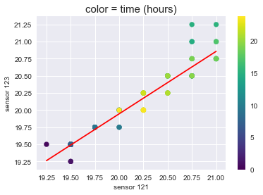

```python
# Calculation of the LinearRegression model and parameters
s121.regress_OLS(s123, day='2017-01-02', comment=True)
# Plot of the regression function, which is a line ax + b (gives s123 temp knowing s121 temp at a given time )
s121.plot_scatter_OLS(s123, day='2017-01-02')
```

#### More generally, we can calculate the correlation between all the sensors of the same room (as a Matrix) - Here for B1

```python
B1.matrix_cor_sensors()
```

|  | n°103/Unité | n°105/% | n°106/% | n°107/% | n°108/% | n°109/% | n°110/% | n°117/None | n°118/None | n°121/°C | n°122/°C |
| --- | --- | --- | --- | --- | --- | --- | --- | --- | --- | --- | --- |
| n°103/Unité | nan | nan | nan | nan | nan | nan | nan | nan | nan | nan | nan |
| n°105/% | nan | 1.00 | 1.00 | 0.03 | nan | nan | nan | -0.10 | 0.83 | 0.45 | 0.21 |
| n°106/% | nan | 1.00 | 1.00 | 0.03 | nan | nan | nan | -0.10 | 0.83 | 0.45 | 0.21 |
| n°107/% | nan | 0.03 | 0.03 | 1.00 | nan | nan | nan | 0.15 | 0.01 | -0.20 | -0.19 |
| n°108/% | nan | nan | nan | nan | nan | nan | nan | nan | nan | nan | nan |
| n°109/% | nan | nan | nan | nan | nan | nan | nan | nan | nan | nan | nan |
| n°110/% | nan | nan | nan | nan | nan | nan | nan | nan | nan | nan | nan |
| n°117/None | nan | -0.10 | -0.10 | 0.15 | nan | nan | nan | 1.00 | -0.18 | -0.24 | -0.22 |
| n°118/None | nan | 0.83 | 0.83 | 0.01 | nan | nan | nan | -0.18 | 1.00 | 0.54 | 0.24 |
| n°121/°C | nan | 0.45 | 0.45 | -0.20 | nan | nan | nan | -0.24 | 0.54 | 1.00 | 0.74 |
| n°122/°C | nan | 0.21 | 0.21 | -0.19 | nan | nan | nan | -0.22 | 0.24 | 0.74 | 1.00 |

## C - Future prediction with statsmodel ARIMA and SARIMAX

### Use case C1 : try to forecast next future values of a temperature time (January/Feb 2017) series with ARIMA and SARIMAX models - Two cases of prediction on the same interval :

- "One step ahead" : the model predict only the next step value from the last real one
- "dynamique" : extrapolation on the whole interval from data before the interval (more difficult, less accurate)

#### Import statsmodel and pmdarima module

```python
# API which enables to call the majority of statsmodel functions
import statsmodels.api as sm
# import of ARIMA module
from statsmodels.tsa.arima_model import ARIMA
# import of SARIMAX (for taking into account seasonality)
from statsmodels.tsa.statespace.sarimax import SARIMAX
# this Python module inspired from R permits to optimise ARIMA parameters automatically
import pmdarima as pm
from pmdarima import model_selection
```

#### Dimensionality reduction of sensor s121 time serie (2 months) : downsampling from 4 to 1 point / hour (24 by day)

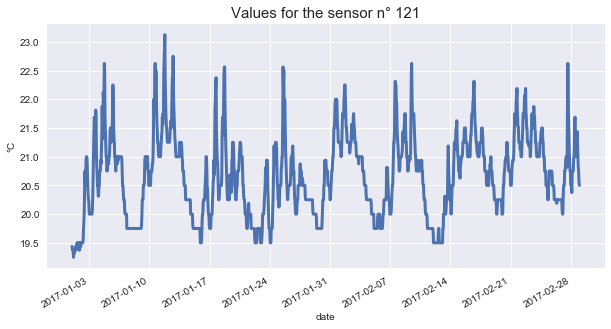

```python
s121.resample_by_hour(transform=True)
s121.plot(transform=True)
```

#### ARIMA (based on autocorrelation) also enables to take into account and "exogenous" parameter - The correlation matrix of the room B1 (room of sensor 121) enables to see if another sensor of the same room could be interested to test with ARIMAX

```python
B1_cor = B1.matrix_cor_sensors()
#B1_cor = B1_cor.replace('nan', 0)
print(B1_cor)
```

```
            n°103/Unité n°105/% n°106/% n°107/% n°108/% n°109/% n°110/%  \
n°103/Unité         nan     nan     nan     nan     nan     nan     nan
n°105/%             nan    1.00    1.00    0.03     nan     nan     nan
n°106/%             nan    1.00    1.00    0.03     nan     nan     nan
n°107/%             nan    0.03    0.03    1.00     nan     nan     nan
n°108/%             nan     nan     nan     nan     nan     nan     nan
n°109/%             nan     nan     nan     nan     nan     nan     nan
n°110/%             nan     nan     nan     nan     nan     nan     nan
n°117/None          nan   -0.10   -0.10    0.15     nan     nan     nan
n°118/None          nan    0.83    0.83    0.01     nan     nan     nan
n°121/°C            nan    0.45    0.45   -0.20     nan     nan     nan
n°122/°C            nan    0.21    0.21   -0.19     nan     nan     nan

            n°117/None n°118/None n°121/°C n°122/°C
n°103/Unité        nan        nan      nan      nan
n°105/%          -0.10       0.83     0.45     0.21
n°106/%          -0.10       0.83     0.45     0.21
n°107/%           0.15       0.01    -0.20    -0.19
n°108/%            nan        nan      nan      nan
n°109/%            nan        nan      nan      nan
n°110/%            nan        nan      nan      nan
n°117/None        1.00      -0.18    -0.24    -0.22
n°118/None       -0.18       1.00     0.54     0.24
n°121/°C         -0.24       0.54     1.00     0.74
n°122/°C         -0.22       0.24     0.74     1.00
```

#### Sensor 122 (heating floor) has logically a quite good correlation (0,74) with s121 (heating influences temperature !) - We make the same downsampling on it to have the same timeseries for the next models

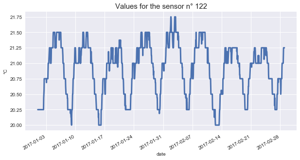

```python
s122.resample_by_hour(transform=True)
s122.plot(transform=True)
```

#### We split the two-months time series in train (until February 14th) and test (rest of February)

rem : predictions can be made either on both, it will be done on the last 2 days of the train for the moment

```python
s121_train = s121.get_value_serie(transform=True)['2017-01-01':'2017-02-14']
s121_test = s121.get_value_serie(transform=True)['2017-02-15':'2017-02-28']
s122_train = s122.get_value_serie(transform=True)['2017-01-01':'2017-02-14']
```

```python
s121.plot_decompose(24, transform=True)
```

[output not shown]

#### First part on ARIMA only : don't take into account the daily seasonality (see next part with SARIMAX)

#### First thing to do (after dim. reduction) is to test the stationarity of the time serie, with the AD-Fuller test (the second figure must be small, near to 0)

```python
adf = s121.adfuller(transform=True)
print(adf)    # It seems that the original serie is stationary (d = 0 in ARIMA)
adf2 = s121.adfuller(transform=True, diff=True)
print(adf2)
```

```
(-4.3182725372181325, 0.0004129373013660928, 24, 1392, {'1%': -3.435056465447021, '5%': -2.8636185648927617, '10%': -2.567876622097536}, -1360.1179844794988)
(-6.806005165071188, 2.175964525942565e-09, 24, 1391, {'1%': -3.4350598552339706, '5%': -2.8636200607815403, '10%': -2.5678774186991347}, -1351.8398527797694)
```

#### Now, we have to determine the order of AR(p) and of MA(q) - Aucorelation Function (ACF) and partial ACF can help

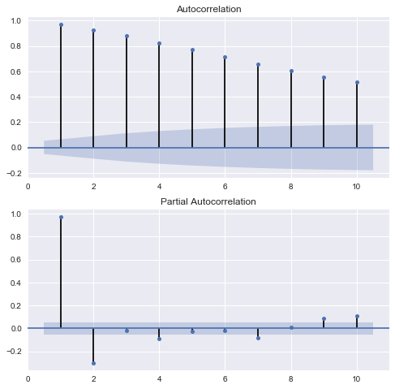

```python
s121.plot_acf_pacf(transform=True)
```

#### According to ACF and PACF, p could be 2 (or 4) and q=0, so ARIMA(2, 0, 0) - But it is better to check what is the optimal combination with auto_arima

```python
auto_arima_results = pm.auto_arima(s121_train, start_p=1, start_q=0,
                     max_d=1, max_p=5, max_q=5,
                     stepwise=True, suppress_warnings=True, D=10, max_D=10,
                     error_action='ignore', seasonal=False)
print(auto_arima_results)
```

```
ARIMA(order=(4, 0, 0), suppress_warnings=True)
```

#### The result is (p, d, q) = (4, 0, 0), which more or less confirms our manual estimation with AD-Fuller and ACF-PACF. Now we come to create and fit an ARIMA (manual) model with these optimized orders

```python
model_arima = ARIMA(s121_train, order=(4,0,0))
results_arima = model_arima.fit()
```

#### The latter ARIMA is only a correlation of s121 with itself - In the next one, we create an ARIMAX instance model which integrates s122 (heating) as an external data serie

```python
model_arimax = ARIMA(s121_train, order=(4,0,0), exog=s122_train)
results_arimax = model_arimax.fit()
```

#### Now we can test and compare a forecast (on the last 48 hours of the train set) with 3 options :

- "one step ahead" prediction with ARIMA
- "dynamic" prediction with ARIMA
- "dynamic" prediction with ARIMAX

```python
forecast_osa = results_arima.predict(start=-48)
forecast_dyn = results_arima.predict(start=-48, dynamic=True)
forecast_dyn_exog = results_arimax.predict(start=-48, dynamic=True)
```

#### Then, in order to compare the forecast with the real data, and the dynamic forecast in the two cases (with or without and external), we plot everything in a same graphic

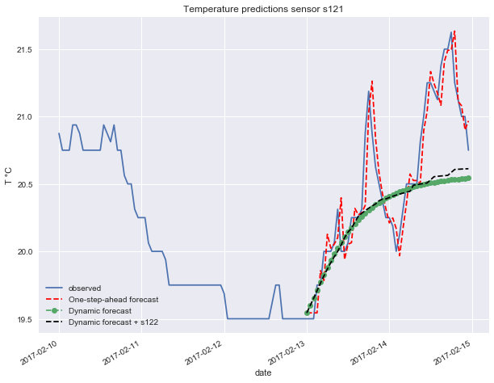

```python
# création de la figure, avec son axe x unique
fig, ax = plt.subplots(figsize=(10,8))
# avec ces titres et labels principaux
ax.set(title='Temperature predictions sensor s121', xlabel='Date',
               ylabel='T °C')
# Affichage des observations sur les 5 derniers jours (10 au 14 février)
s121_train.loc['2017-02-10':].plot(ax=ax, label="observed")
# Affiche des prédictions "one step ahead" pour les deux derniers jours
forecast_osa.loc['2017-02-13':].plot(ax=ax, style='r--',
                          label="One-step-ahead forecast")
# Affiche des prédictions "dynamic" ARIMA pour les deux derniers jours
forecast_dyn.loc['2017-02-13':].plot(ax=ax, style='o--',
                                    label="Dynamic forecast")
# Affiche des prédictions "dynamic" ARIMAX  pour les deux derniers jours
forecast_dyn_exog.loc['2017-02-13':].plot(ax=ax, style='k--',
                                     label="Dynamic forecast + s122")
# positionnement de la légende
legend = ax.legend(loc='lower left')
```

#### Provisional conclusions - We remark with no big surprise that :

- one step ahead (read) correctly extrapolates next data from the 4 previous one (but this result should be studied in more details)
- dynamic forecast gives quite a correct global trend, but does not follow the daily pattern
- the difference with "exog" (other sensor) is not really significative, but it can't radically change the general trend

#### Now we can hope to improve the model mainly by taking into account the daily pattern (due to heating !), especially for the dynamic (long term) forecast

#### Firstly, we directly calculates the optimized orders for SARIMAX (too complicated and risky with manual methods) - Despite we limit the range of values for certain orders, this calculation is quite long (several minutes) and we give directly the results

```python
auto_sarimax_results = pm.auto_arima(s121_train,
                  # les ordres min/max ARMA en normal et seasonal
                  start_p=1, start_q=0, start_P=1, start_Q=0,
                  max_p=5, max_q=5, max_P=5, max_Q=5,
                  seasonal=True,
                  # les ordres max de differencing pour que ce soit stationaire
                  max_d=1, max_D=2,
                  # fréquence de retour - 24 / jours
                  m=24,
                  stepwise=True, suppress_warnings=True, error_action='ignore')
print(auto_sarimax_results)
```

```
ARIMA(order=(1, 0, 0), seasonal_order=(2, 0, 1, 24), suppress_warnings=True)
```

#### The result is : ARIMA(order=(1, 0, 0), seasonal_order=(2, 0, 1, 24)) - We notice that p=1 only now (4 for the ARIMA without seasonal), probably because the daily period is more important. Then we create the corresponding SARIMAX

```python
model_sarima = SARIMAX(s121_train, order=(1,0,0), seasonal_order=(2, 0, 1, 24),
                trend='c')
results_sarima = model_sarima.fit()
# attention le calcul est long, c'est pourquoi on fait un print pour attendre la fin avant de poursuivre
print(results_sarima)
```

```
<statsmodels.tsa.statespace.sarimax.SARIMAXResultsWrapper object at 0x0000021E66B08C50>
```

#### The SARIMAX modules offers more tools than ARIMA. Among them a diagnosis visual tool with 4 parameters to evaluate the quality of the model (not commented here), which can be complementary to displaying forecast and compare it to actual data (see next step)

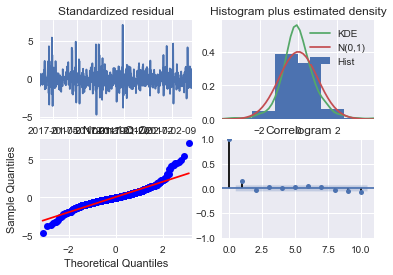

```python
results_sarima.plot_diagnostics()
plt.show()
```

#### Making the forecast with the SARIMAX model (same than with ARIMA + confidence interval)

```python
# Prédiction one-step-ahead
forecast_osa = results_sarima.get_prediction(start=-48)
#forecast_dyn = results_arima.predict(start=-48, dynamic=True)
mean_forecast_osa = forecast_osa.predicted_mean
# intervalle de confiance associé à la prédiction
osa_ci = forecast_osa.conf_int()

# Prédiction dynamique
# forecast_dyn = results_arima.get_prediction(dynamic='2017-02-13')
forecast_dyn = results_sarima.get_prediction(start=-48, dynamic=True)
#forecast_dyn = results_arima.predict(start=-48, dynamic=True)
mean_forecast_dyn = forecast_dyn.predicted_mean
# intervalle de confiance associé à la prédiction
dyn_ci = forecast_dyn.conf_int()
```

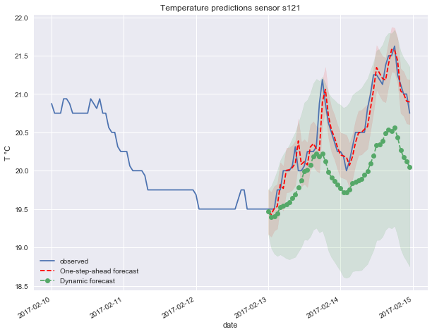

```python
# création de la figure, avec son axe x unique
fig, ax = plt.subplots(figsize=(10,8))
# avec ces titres et labels principaux
ax.set(title='Temperature predictions sensor s121', xlabel='Date',
               ylabel='T °C')
# Affichage des observations sur les 5 derniers jours (10 au 14 février)
s121_train.loc['2017-02-10':].plot(ax=ax, label="observed")
# Affiche des prédictions "one step ahead" pour les deux derniers jours
mean_forecast_osa.loc['2017-02-13':].plot(ax=ax, style='r--',
                          label="One-step-ahead forecast")
# avec l'intervalle de confiance
ax.fill_between(osa_ci.index, osa_ci.iloc[:,0], osa_ci.iloc[:,1],
                color='r', alpha=0.1)

# Affiche des prédictions "dynamic" ARIMA pour les deux derniers jours
mean_forecast_dyn.loc['2017-02-13':].plot(ax=ax, style='o--',
                                    label="Dynamic forecast")
# Affiche des prédictions "dynamic" ARIMAX  pour les deux derniers jours
#forecast_dyn_exog.loc['2017-02-13':].plot(ax=ax, style='k--',
#                                    label="Dynamic forecast + s122")
# avec l'intervalle de confiance
ax.fill_between(dyn_ci.index, dyn_ci.iloc[:,0], dyn_ci.iloc[:,1],
                color='g', alpha=0.1)
# positionnement de la légende
legend = ax.legend(loc='lower left')
```

#### Provisional conclusions on SARIMAX and future improvements :

- the main difference with SARIMA is that the dynamic forecast follow the shape of the real data (daily trend), the underestimation is probably due that the 2 days are weekly days, whereas the average is lower due to WE : we should take into account the day of the week ! (next improvement)
- for the "one step ahead", we should calculate the difference between real data, ARIMA and SARIMAX estimation on the whole interval to better estimate it